# RGroup

Vit Grigoriev

2018-11-17

## Получение графа группы

Мы используем пакеты **RCurl** и **jsonlite** чтобы выгрузить данные группы и превратить их в привычный датафрейм.

```r
library(RCurl)
library(jsonlite)
d = postForm('https://api.vk.com/method/groups.getMembers',
             group_id="rseminar_spb",
             v=5.74,
             # замените мой токен на свой. http://zenno.pro/kak-poluchit-access-token-prilozheniya-vk-com/
             access_token =  '...'
)

rd  <- fromJSON(d, flatten = TRUE)
d=as.data.frame(rd, optional = TRUE)
d=d$response.items
```

Чтобы построить граф, создадим таблицу из двух колонок, каждая строка это пользователи, связанные дружеской связью. Цикл проходит всех членов группы, находит друзей каждого, оставляет только тех, кто в группе.

```r
df= data.frame(to=integer(0), from=numeric(0))
n=0
for (id in d) {
  ri=postForm('https://api.vk.com/method/friends.get',
              user_id=id,
              v=5.74,
              # замените мой токен на свой. http://zenno.pro/kak-poluchit-access-token-prilozheniya-vk-com/
              access_token = '...'
  )
  rdi  <- fromJSON(ri, flatten = TRUE)
  if (!is.null(rdi$response$count)) {
    if (rdi$response$count!=0) {
      di=as.data.frame(rdi, optional = TRUE)
      to=di[ (di[[2]] %in% d) & id<di[[2]], 2]
      if(length(to)!=0) {
        from=id
        d1=data.frame(to, from)
        df = rbind.data.frame(df, d1)
        # print(paste(length(d)-n, id))
        n=n+1
      }
    }
  }
  Sys.sleep(0.35) # 3 запроса в секунду
}
```

Цикл содержит проверки (там где **if**), что аккаунт существует и что у персоны вообще есть друзья.

Чтобы не возбуждать сервера ВКонтакте я ограничился тремя запросами в секунду.

Теперь у нас есть датафрейм с очень простой структурой. Названия столбцов традиционны для пакета **igraph**, который мы используем, чтобы провести анализ сети. Но граф у нас всё равно ненаправленный.

```r
head(df)
```

```
##        to from
## 1  403284 2669
## 2 1343779 2669
## 3 1353829 2669
## 4 4206848 2669
## 5    7462 3463
## 6  126312 3463
```

```r
library(igraph)
g=graph_from_data_frame(df, directed = FALSE, vertices = NULL)
```

# Ну чтоже нам с ним можно сделать?

## 1) Посчитать число участников:

```r
length(V(g))
```

```
## [1] 146
```

## 2)Нарисовать:

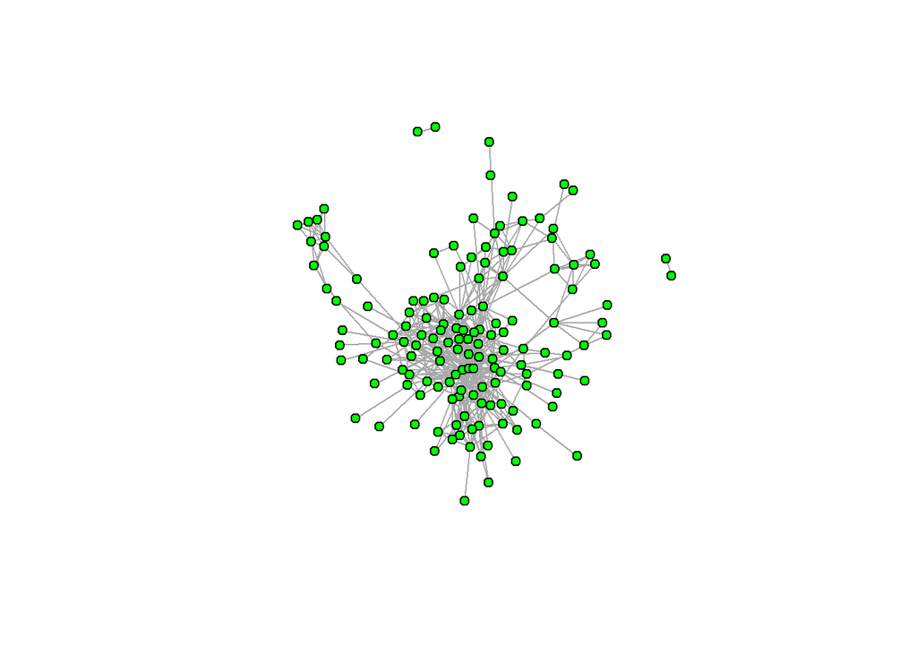

```r
plot(g, vertex.label=NA, vertex.color = 'green', vertex.size=5)
```

или так:

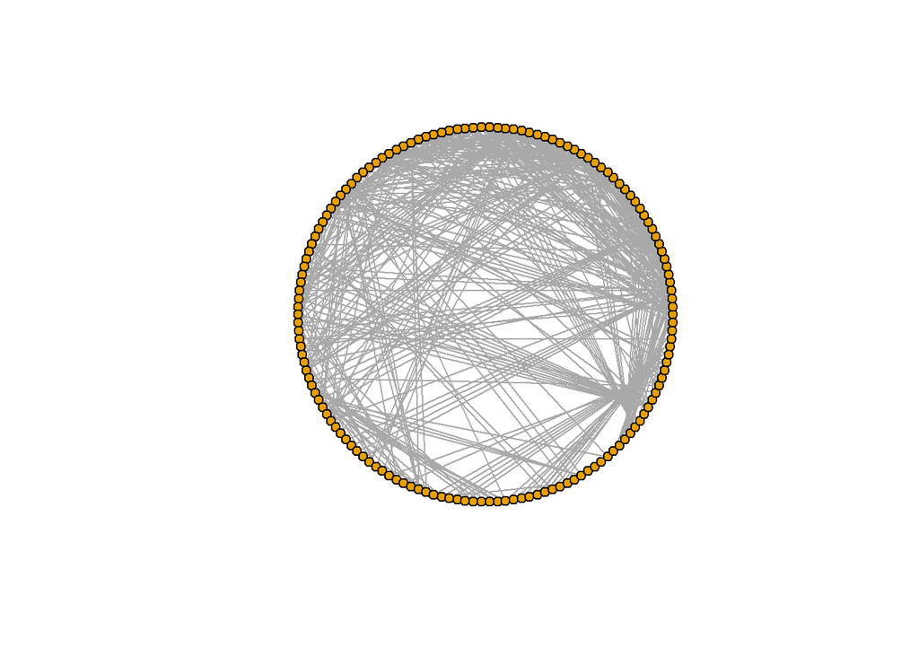

```r
plot(g, layout=layout_in_circle, vertex.size=5, vertex.label=NA)
```

Хочется знать кто где? тогда так:

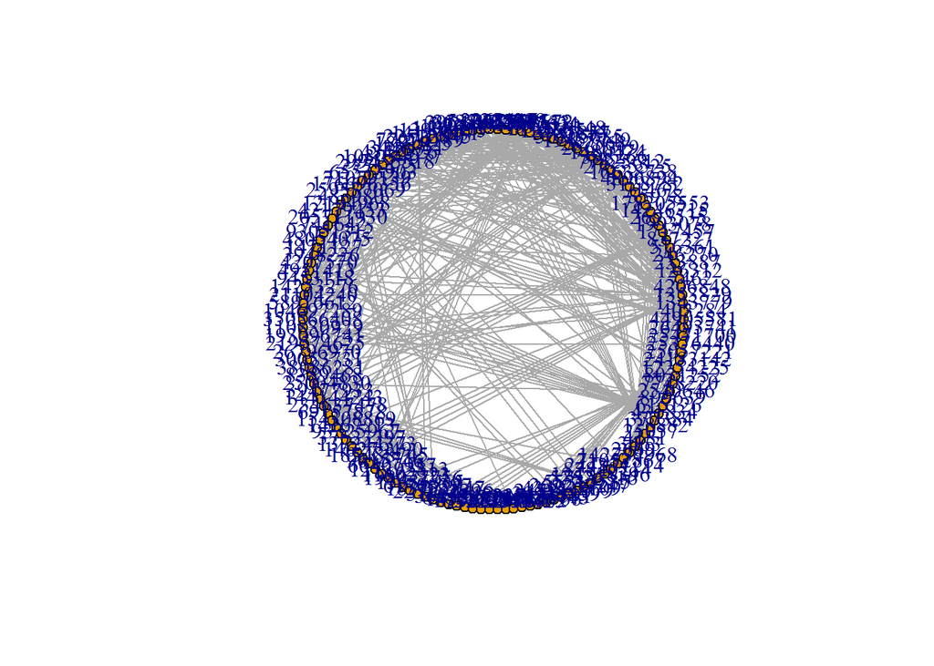

```r
plot(g, layout=layout_in_circle, vertex.size=5, vertex.label.dist=1)
```

Безобразие! Уж лучше бы как раньше. Но если вам захочется превратить номера в имена возьмите названия вершин **V(g)**, воспользуйтесть методом users.get из API Vk и используйте опцию **vertex.label=** чтобы вставить имена пользователей в картинку. А мне что-то не хочется. И вообще графики очень полезны для эксплоративного анализа данных, но в сетевом анализе узлы с ребрами практически бесполезны. Не понимаю зачем их все рисуют.

## 3) степень кластеризации (транзитивность)

```r
transitivity(g) # глобальный коэффициент
```

```
## [1] 0.3314615
```

Это отношения числа треугольников к числу возможных треугольников. Чем больше, тем ближе сообщество к клике. Обычно падает при росте группы. Числа Данбара мы конечно не достигли. Работающие вместе нуждаются в личных связях и получается высокая глобальная транзитивность и группа, у псевдогруппы - типа лидер и последователи - транзитивность маленькая.

```r
transitivity(g, type="local") # локальный
```

```
##   [1] 0.2486772 0.3111111 0.4000000 0.1333333 0.2575758 0.3676471 0.3333333
##   [8] 0.5333333 0.2857143       NaN       NaN 0.2000000 0.4285714       NaN
##  [15] 0.3333333 0.4000000 0.3055556 0.4909091 0.3463203 0.5000000 0.4666667
##  [22] 0.3333333 0.2833333 0.2153846 0.4848485 0.3003953 0.6000000 0.0000000
##  [29] 0.6000000 0.3928571 0.5000000 0.7000000 0.4545455 0.2789855 0.4222222
##  [36] 0.3161765 0.4285714 0.3583333 0.5714286 0.4666667 0.7333333       NaN
##  [43] 0.0000000       NaN 0.9523810 0.7051282 0.3216374 0.3333333 1.0000000
##  [50] 0.4035088 0.6666667 0.5809524       NaN 0.0000000 0.2000000 0.1333333
##  [57] 0.3619048 0.1538462 0.1666667 0.5000000 0.5757576       NaN 0.0000000
##  [64]       NaN 0.3333333 0.7111111 0.7222222 0.6666667 0.7500000 0.6545455
##  [71] 0.5555556 0.6000000 0.4835165 0.6444444 0.5272727 0.2000000 0.0000000
##  [78]       NaN 0.2666667 0.6666667 0.4909091 0.0000000 0.4666667 0.2380952
##  [85] 0.3214286 0.4285714 0.6666667 0.2666667       NaN       NaN 0.3333333
##  [92] 1.0000000       NaN 0.3000000 1.0000000 0.3928571       NaN       NaN
##  [99] 1.0000000 0.0000000 1.0000000 0.3000000 0.0000000       NaN 0.3809524
## [106] 0.3333333 1.0000000 1.0000000 0.6000000 1.0000000 1.0000000 0.3000000
## [113] 0.2666667       NaN       NaN 0.3333333 0.5000000 0.5000000 0.6000000
## [120] 0.7333333 0.1666667 0.0000000 0.6000000 0.9000000 1.0000000       NaN
## [127] 0.0000000 0.6666667 0.7000000 0.1666667 1.0000000 0.5714286       NaN
## [134]       NaN 0.5333333 1.0000000       NaN 0.0000000       NaN       NaN
## [141] 0.0952381 0.0000000       NaN 0.4000000 1.0000000       NaN
```

```r
V(g)[10]
```

```
## + 1/146 vertex, named, from d4814b4:
## [1] 837227
```

```r
neighbors(g, 10)
```

```
## + 1/146 vertex, named, from d4814b4:
## [1] 4181
```

Если вы перезнакомили всех знакомых между собой у вас получится локальная транзитивность высокая. Или если вы никогда не ходите в незнакомые компании.

Средняя транзитивность:

```r
transitivity(g, type = "average")
```

```
## [1] 0.4559705
```

вообще не знаю зачем это нужно.

## 4) Плотность ребер = реальное количество ребер / максимально возможное. Тоже говорит о том насколько мы близки к клике. Если держать плотность, а транзитивность увеличивать сообщество начнет распадаться на подгруппы. Так что плотность и транзитивность - несколько разная информация.

```r
edge_density(g, loops=F)
```

```
## [1] 0.04855928
```

## 5) Диаметр = самый длинный путь в связанной части графа между двумя узлами. что-то вроде тесноты. Маленький диаметр = тесный мир.

```r
diameter(g, directed=F) # длина самого длинного пути
```

```
## [1] 8
```

Первый длинный путь

```r
(diam <- get_diameter(g, directed=F))
```

```
## + 9/146 vertices, named, from d4814b4:
## [1] 159860766 25057221  259537069 1993078   4206848   576361    48054075
## [8] 247211079 269253247
```

На картинке мы его можем нарисовать:

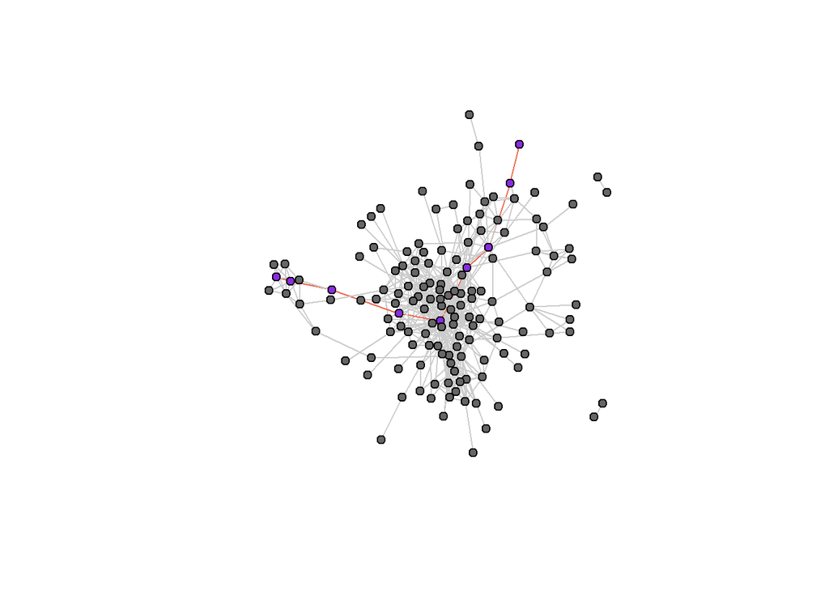

```r
vcol <- rep("gray40", vcount(g))
vcol[diam] <- "blueviolet"
ecol <- rep("gray80", ecount(g))
ecol[E(g, path=diam)] <- "coral2"
plot(g, vertex.color=vcol, edge.color=ecol, vertex.size=5, vertex.label=NA)
```

## 6) Степени узлов. Это у кого сколько ребер. Можно изобразить на гистограмме:

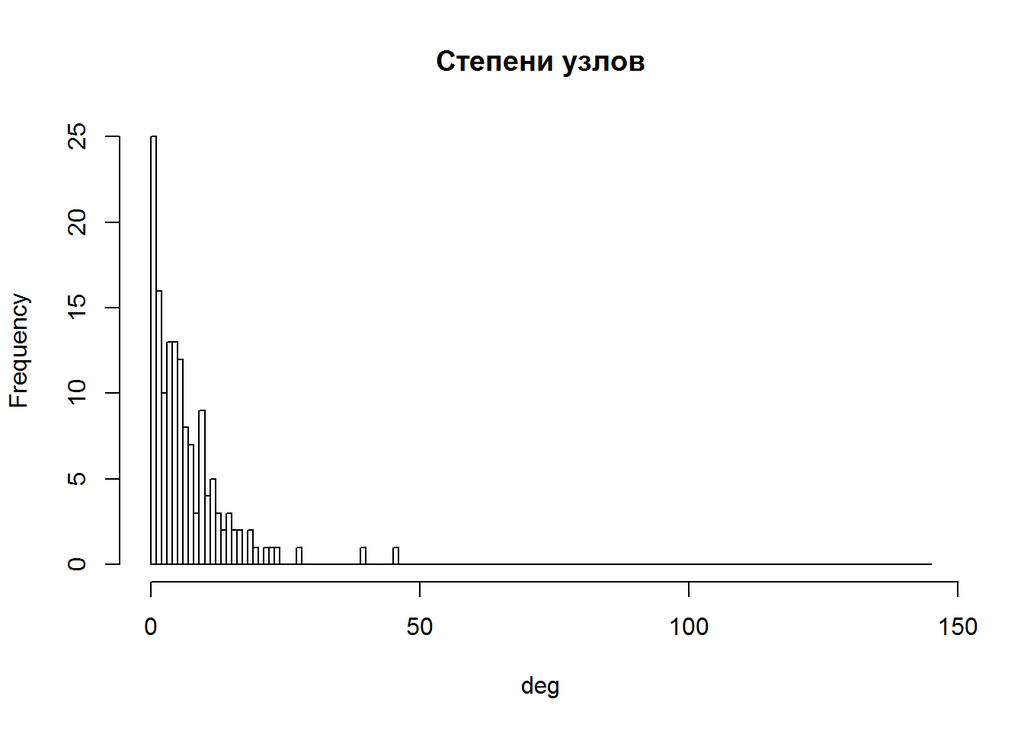

```r
deg <- degree(g, mode="all")
hist(deg, breaks=1:vcount(g)-1, main="Степени узлов")
```

А можно использовать в картинке графа, для эмоциональной выразительности. В конце концов, если вы не знаете зачем вы все это делаете, хотя бы произведите загадочное впечатление на аудиторию:

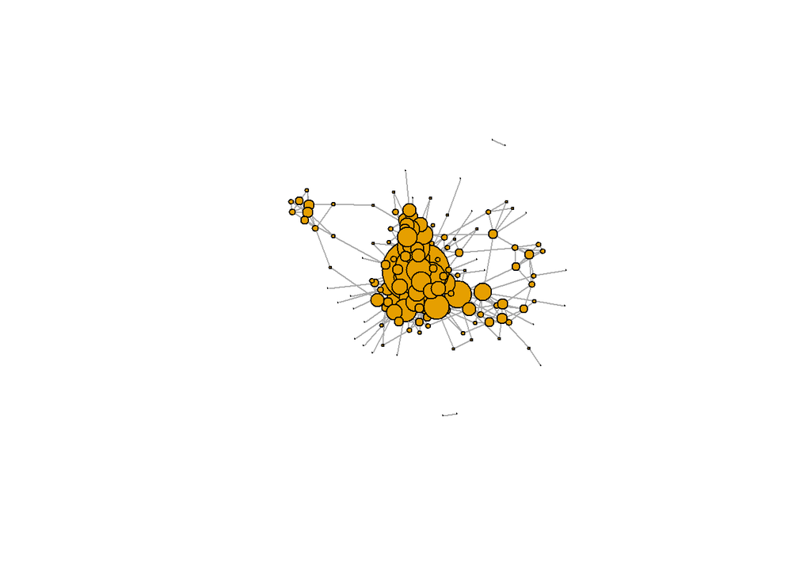

```r
plot(g, vertex.size=deg*1, vertex.label=NA)
```

## Важность узла

7а Центральность и централизация по степеням узлов

```r
centr_degree(g, mode="in", normalized=T)
```

```
## $res
##   [1] 28 10 10 46 12 17  6  6  7  1  1 20  7  1  4  6  9 11 22  9 10  3 16
##  [24] 40 12 23  5  3  5  8 13  5 12 24 10 17  7 16 14  6  6  1  2  1  7 13
##  [47] 19  3  4 19  6 15  1  2  5 10 15 13  4  4 12  1  2  1  3 10  9  4  8
##  [70] 11 10  5 14 10 11  6  2  1 10  4 11  2  6  7  8  8  3  6  1  1  3  2
##  [93]  1  5  2  8  1  1  2  2  2  5  3  1  7  4  2  2  5  4  4  5  6  1  1
## [116]  3  8  8  6  6  4  2  5  5  4  1  2  4  5 12  4  7  1  1 15  2  1  2
## [139]  1  1  7  3  1  5  3  1
##
## $centralization
## [1] 0.2686821
##
## $theoretical_max
## [1] 21170
```

**`res`** - это просто степени узлов. Чем больше, тем очевидно центральнее. Эту информацию мы уже видели. **centralization** - получается если от максимальной степени узла в сети отнять степень каждого узла, все сложить и поделить на максимально возможную при таких размерах. Самый остепененный узел выступает тут точкой отсчета. В регулярной решетке степени всех узлов одинаковы и централизация = 0. Максимальная централизация, если есть звезда, и никто никого кроме неё не знает.  
И ещё там есть теоретический максимум, не знаю зачем. Наверно чтобы проверять умеет ли *R* считать.

7б Близость (обратное среднее рассояние до остальных)

```r
(clo=closeness(g, mode="all", weights=NA))
```

```
##       403284      1343779      1353829      4206848         7462
## 1.100110e-03 1.016260e-03 1.037344e-03 1.158749e-03 1.038422e-03
##       126312       233887       246270       576361       837227
## 1.074114e-03 1.035197e-03 1.019368e-03 1.057082e-03 9.302326e-04
##      1717457      1993078      2693535     14246715    178205553
## 9.302326e-04 1.103753e-03 1.019368e-03 9.302326e-04 9.990010e-04
##        35978        71462      3128782      4896894     16638738
## 9.910803e-04 1.000000e-03 1.063830e-03 1.091703e-03 1.046025e-03
##     27835525     77425612       398266      1480474      2860319
## 1.039501e-03 9.407338e-04 1.097695e-03 1.137656e-03 1.053741e-03
##       287568     19457749     50505685      3985857     12268594
## 1.094092e-03 1.033058e-03 9.523810e-04 1.006036e-03 1.042753e-03
##    171826148       390510      4047624      5207333    318558672
## 1.048218e-03 1.031992e-03 1.058201e-03 1.076426e-03 1.022495e-03
##       273695      1304399      2368417     51741501    258802764
## 1.066098e-03 1.029866e-03 1.071811e-03 1.058201e-03 9.643202e-04
##    296486429      5426441      1090413      1431757     13906675
## 9.718173e-04 9.041591e-04 9.140768e-04 9.276438e-04 1.029866e-03
##     14113081     22512645     77074189      1881825      3446351
## 1.057082e-03 1.068376e-03 9.643202e-04 1.024590e-03 1.076426e-03
##      4342526    103034077    299455518      2771475     65533903
## 1.055966e-03 1.085776e-03 9.487666e-04 9.832842e-04 9.803922e-04
##     71079139    176696356    259537069       483980     12194968
## 1.013171e-03 1.088139e-03 1.044932e-03 1.018330e-03 9.940358e-04
##     42179453    205711930       741642     93051312     48054075
## 1.059322e-03 9.532888e-04 9.157509e-04 8.912656e-04 9.363296e-04
##      1471127      3948226      4207570      4951413      9453118
## 9.852217e-04 9.671180e-04 1.008065e-03 1.033058e-03 1.025641e-03
##     14253276     21104240     58916612    104697289    350566408
## 1.050420e-03 9.425071e-04 1.033058e-03 9.813543e-04 1.031992e-03
##    110830929    193096741    219574625     26796970     30053731
## 1.036269e-03 9.066183e-04 9.057971e-04 1.011122e-03 1.021450e-03
##     38086281      8389468     25004830     39477933    144144243
## 1.030928e-03 9.587728e-04 9.746589e-04 9.737098e-04 9.871668e-04
##    234637478     69157878    154308869     14167213     93325967
## 9.910803e-04 9.250694e-04 1.040583e-03 9.216590e-04 9.216590e-04
##     37523397    137244373    146279490    185488745      9615746
## 1.007049e-03 1.003009e-03 9.970090e-04 1.022495e-03 9.460738e-04
##     66407957    127392813     11602323    198077756     13636965
## 9.587728e-04 9.354537e-04 4.756243e-05 9.460738e-04 8.688097e-04
##     61706397    183722047    227182296     31224632     36852482
## 9.033424e-04 9.765625e-04 9.689922e-04 8.810573e-04 9.165903e-04
##     89853399    145567959    177217848     29421496     33733157
## 9.354537e-04 8.849558e-04 8.849558e-04 9.389671e-04 8.787346e-04
##     77924377    114554425     81378602    159860766    101053743
## 8.787346e-04 8.976661e-04 9.017133e-04 8.123477e-04 4.756243e-05
##     37136591     39943859    247211079    434922109    269253247
## 8.628128e-04 7.949126e-04 8.417508e-04 8.403361e-04 7.570023e-04
##     55212535     57576316    124518396     87840714    244371214
## 9.250694e-04 9.606148e-04 9.140768e-04 7.564297e-04 7.558579e-04
##     71052867    142734968         2669         3463         4181
## 8.190008e-04 9.049774e-04 1.021450e-03 1.013171e-03 1.069519e-03
##        25057       128882       377384       431834       615126
## 1.008065e-03 9.746589e-04 8.643042e-04 9.259259e-04 1.053741e-03
##       899639      2540646      7748220      8031252     12254225
## 1.025641e-03 8.628128e-04 9.398496e-04 4.756243e-05 7.745933e-04
##     24183142     25057221     25376440     25471700     26493741
## 1.005025e-03 9.165903e-04 4.756243e-05 8.368201e-04 7.552870e-04
##     44905581
## 8.620690e-04
```

И централизацию всего графа можно посчитать не по степеням узлов, а по близости узлов. Там все аналогично центральности по степеням.

```r
centr_clo(g, mode="all", normalized=T)
```

```
## $res
##   [1] 0.159515952 0.147357724 0.150414938 0.168018540 0.150571132
##   [6] 0.155746509 0.150103520 0.147808359 0.153276956 0.134883721
##  [11] 0.134883721 0.160044150 0.147808359 0.134883721 0.144855145
##  [16] 0.143706640 0.145000000 0.154255319 0.158296943 0.151673640
##  [21] 0.150727651 0.136406397 0.159165752 0.164960182 0.152792413
##  [26] 0.158643326 0.149793388 0.138095238 0.145875252 0.151199166
##  [31] 0.151991614 0.149638803 0.153439153 0.156081808 0.148261759
##  [36] 0.154584222 0.149330587 0.155412647 0.153439153 0.139826422
##  [41] 0.140913508 0.131103074 0.132541133 0.134508349 0.149330587
##  [46] 0.153276956 0.154914530 0.139826422 0.148565574 0.156081808
##  [51] 0.153115100 0.157437568 0.137571157 0.142576205 0.142156863
##  [56] 0.146909828 0.157780196 0.151515152 0.147657841 0.144135189
##  [61] 0.153601695 0.138226883 0.132783883 0.129233512 0.135767790
##  [66] 0.142857143 0.140232108 0.146169355 0.149793388 0.148717949
```

[output cut: 22 more lines]

7в Центральность по первому собственному значению матрицы смежности - пропорциональна сумме центральностей присоединенных узлов.

```r
eigen_centrality(g, directed=T, weights=NA)
```

```
## $vector
##       403284      1343779      1353829      4206848         7462
## 6.806025e-01 1.700301e-01 2.762296e-01 9.360027e-01 2.585752e-01
##       126312       233887       246270       576361       837227
## 4.442684e-01 1.974312e-01 1.351786e-01 1.742847e-01 1.475377e-02
##      1717457      1993078      2693535     14246715    178205553
## 1.475377e-02 4.013995e-01 1.720773e-01 1.475377e-02 9.719890e-02
##        35978        71462      3128782      4896894     16638738
## 1.108302e-01 1.827699e-01 3.611321e-01 5.965364e-01 3.002610e-01
##     27835525     77425612       398266      1480474      2860319
## 3.067657e-01 5.818691e-02 4.187680e-01 1.000000e+00 3.444843e-01
##       287568     19457749     50505685      3985857     12268594
## 6.253696e-01 1.341141e-01 4.404743e-02 1.905367e-01 2.700047e-01
##    171826148       390510      4047624      5207333    318558672
## 4.237776e-01 1.951686e-01 4.073746e-01 5.716266e-01 2.620107e-01
##       273695      1304399      2368417     51741501    258802764
## 4.240619e-01 1.816730e-01 3.773148e-01 4.425900e-01 9.363578e-02
##    296486429      5426441      1090413      1431757     13906675
## 1.366362e-01 1.329142e-02 1.722570e-02 2.854861e-02 2.706372e-01
##     14113081     22512645     77074189      1881825      3446351
## 4.796668e-01 4.984049e-01 8.247960e-02 1.513495e-01 6.033307e-01
##      4342526    103034077    299455518      2771475     65533903
## 2.213814e-01 5.612244e-01 4.210101e-02 6.762831e-02 4.313819e-02
##     71079139    176696356    259537069       483980     12194968
## 1.199780e-01 3.246548e-01 1.492934e-01 1.104456e-01 1.206925e-01
##     42179453    205711930       741642     93051312     48054075
## 3.965957e-01 4.581939e-02 1.652171e-02 7.435398e-03 1.186651e-02
##      1471127      3948226      4207570      4951413      9453118
## 1.863743e-01 1.503187e-01 1.107427e-01 3.086296e-01 2.448830e-01
##     14253276     21104240     58916612    104697289    350566408
## 3.198297e-01 9.939040e-02 2.929218e-01 1.680432e-01 2.131083e-01
##    110830929    193096741    219574625     26796970     30053731
## 1.349684e-01 1.151661e-02 1.859628e-02 2.200992e-01 1.569868e-01
##     38086281      8389468     25004830     39477933    144144243
## 3.376838e-01 2.941514e-02 2.926382e-02 4.504671e-02 4.678596e-02
##    234637478     69157878    154308869     14167213     93325967
## 5.392664e-02 5.139897e-02 1.393246e-01 2.742519e-02 2.742519e-02
##     37523397    137244373    146279490    185488745      9615746
## 8.649098e-02 7.209970e-02 6.301339e-02 9.648579e-02 5.666014e-02
##     66407957    127392813     11602323    198077756     13636965
```

[output cut: 70 more lines]

```
##
## $options$iter
## [1] 2
##
## $options$nconv
## [1] 1
##
## $options$numop
## [1] 30
##
## $options$numopb
## [1] 0
##
## $options$numreo
## [1] 21
```

```r
eig=centr_eigen(g, directed=T, normalized=T)
```

7г Центральность по промежуточности = количеству геодезических линий, проходящих через узел.

```r
(bet=betweenness(g, directed=T, weights=NA))
edge_betweenness(g, directed=T, weights=NA)
centr_betw(g, directed=T, normalized=T)
```

[output not shown]

Корреляции центральностей:

```r
cor(data.frame(deg, bet, clo, eig[1]))
```

```
##              deg       bet       clo    vector
## deg    1.0000000 0.7582652 0.4380667 0.9261327
## bet    0.7582652 1.0000000 0.2839365 0.5969150
## clo    0.4380667 0.2839365 1.0000000 0.4867801
## vector 0.9261327 0.5969150 0.4867801 1.0000000
```

Все меры центральность про одно и тоже, но слегка по-разному

## 8. Расстояния.

Среднее расстояние между узлами

```r
mean_distance(g)
```

```
## [1] 3.189254
```

Кратчайшие пути между узлами, первые 10, а то слишком много будет в тексте

```r
distances(g)[1:10,1:10]
```

```
##         403284 1343779 1353829 4206848 7462 126312 233887 246270 576361
## 403284       0       1       1       1    2      2      1      2      1
## 1343779      1       0       2       2    3      2      1      2      2
## 1353829      1       2       0       1    1      1      2      2      2
## 4206848      1       2       1       0    1      1      1      1      1
## 7462         2       3       1       1    0      1      2      1      2
## 126312       2       2       1       1    1      0      2      1      2
## 233887       1       1       2       1    2      2      0      2      2
## 246270       2       2       2       1    1      1      2      0      2
## 576361       1       2       2       1    2      2      2      2      0
## 837227       2       2       3       2    3      2      3      2      2
##         837227
## 403284       2
## 1343779      2
## 1353829      3
## 4206848      2
## 7462         3
## 126312       2
## 233887       3
## 246270       2
## 576361       2
## 837227       0
```

Расстояние до Кнорре

```r
(doKn = distances(g, v=V(g)['4206848'], to=V(g)))
```

```
##         403284 1343779 1353829 4206848 7462 126312 233887 246270 576361
## 4206848      1       2       1       0    1      1      1      1      1
##         837227 1717457 1993078 2693535 14246715 178205553 35978 71462
## 4206848      2       2       1       2        2         2     2     2
##         3128782 4896894 16638738 27835525 77425612 398266 1480474 2860319
## 4206848       1       2        1        1        2      1       1       1
##         287568 19457749 50505685 3985857 12268594 171826148 390510 4047624
## 4206848      1        1        3       2        1         2      1       1
##         5207333 318558672 273695 1304399 2368417 51741501 258802764
## 4206848       1         2      1       1       2        1         2
##         296486429 5426441 1090413 1431757 13906675 14113081 22512645
## 4206848         2       2       2       2        2        1        2
##         77074189 1881825 3446351 4342526 103034077 299455518 2771475
## 4206848        2       2       1       1         1         2       2
##         65533903 71079139 176696356 259537069 483980 12194968 42179453
```

[output cut: 25 more lines]

С рисунком:

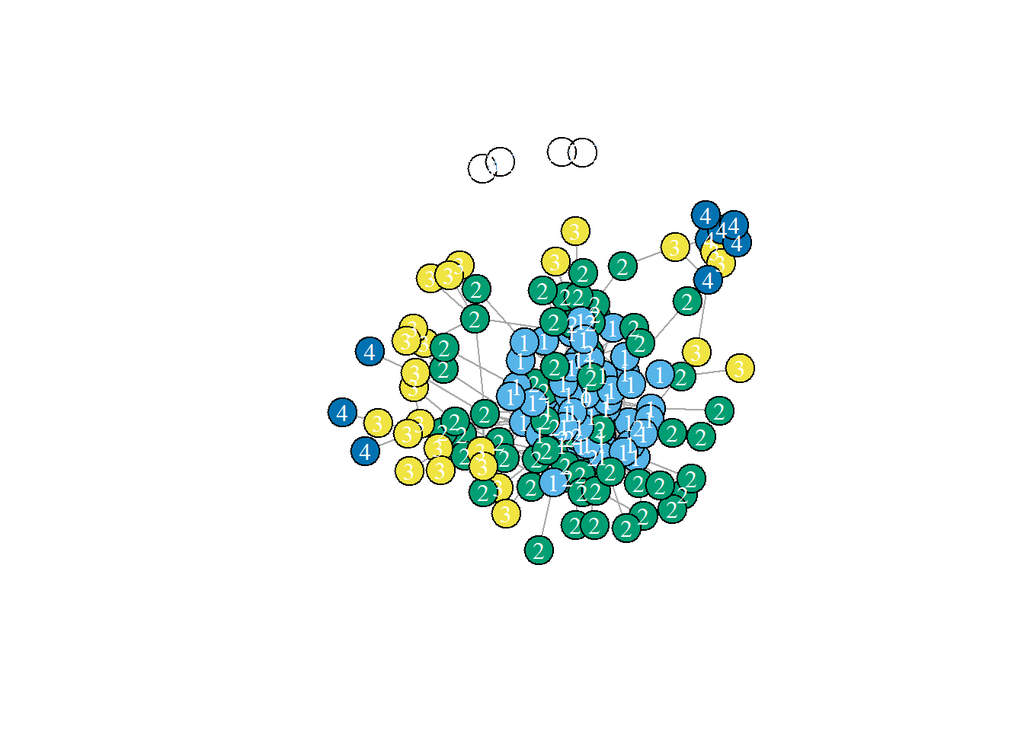

```r
col <- doKn+1
plot(g, vertex.color=col, vertex.label=doKn, vertex.label.color="white")
```

## 9. Клики (это когда все со всеми)

Список клик (слишком длинный, чтобы быть полезным:

```r
cliques(g)
```

Размер клик:

```r
sapply(cliques(g), length)
```

```
##    [1] 1 1 1 1 1 1 1 1 1 1 1 1 1 1 1 1 1 1 1 1 1 1 1 1 1 1 1 1 1 1 1 1 1 1
##   [35] 1 1 1 1 1 1 1 1 1 1 1 1 1 2 2 2 2 2 2 2 1 2 2 1 2 2 2 2 1 2 2 2 2 2
##   [69] 1 2 2 1 2 2 1 2 2 1 2 1 2 1 2 2 1 2 1 2 2 1 2 2 1 2 2 2 2 1 2 1 2 2
##  [103] 1 2 1 2 1 2 1 2 1 2 2 1 2 1 2 1 2 2 2 1 2 1 2 1 2 2 1 2 1 2 1 2 1 2
##  [137] 1 2 2 1 2 1 2 1 2 3 3 2 2 2 2 1 2 3 2 3 2 3 3 2 3 3 2 3 3 2 2 2 2 1
##  [171] 2 3 3 3 2 2 2 2 2 1 2 3 3 2 2 2 1 2 2 3 2 1 2 3 2 3 3 2 2 1 2 3 2 1
##  [205] 2 3 2 1 2 3 2 2 2 1 2 3 3 2 2 1 2 3 2 2 1 2 3 2 1 2 3 3 2 2 1 2 3 2
##  [239] 3 2 2 1 2 2 3 3 2 2 1 2 3 3 2 2 2 1 2 3 2 2 1 2 3 2 1 2 3 2 1 2 3 2
##  [273] 3 4 4 3 3 2 3 4 3 2 3 4 3 2 3 4 3 2 3 4 3 2 3 3 2 2 2 2 1 2 3 3 4 3
##  [307] 2 3 4 4 3 3 2 3 2 3 3 2 3 3 2 2 1 2 3 4 3 2 3 4 4 3 3 2 3 3 2 2 1 2
##  [341] 3 4 3 2 3 3 2 2 2 2 1 2 3 4 3 2 3 2 1 2 3 2 3 2 3 2 3 2 2 1 2 3 3 3
##  [375] 2 3 3 2 3 3 2 2 2 2 2 2 2 2 1 2 3 4 3 2 3 2 2 2 1 2 3 4 3 2 3 2 1 2
##  [409] 3 4 3 2 2 3 2 2 2 1 2 3 2 3 2 2 2 1 2 3 2 3 3 2 3 2 2 2 1 2 3 4 3 2
##  [443] 3 4 3 2 3 4 3 3 2 3 2 2 2 1 2 3 2 2 1 2 3 2 3 4 3 3 2 3 2 2 2 1 2 3
##  [477] 2 3 2 3 4 3 2 2 3 2 1 2 3 4 3 2 3 2 3 2 2 1 2 3 4 3 2 3 2 1 2 3 2 3
```

[output cut: 61 more lines]

Самые большие:

```r
largest_cliques(g)  # самые большие
```

```
## [[1]]
## + 8/146 vertices, named, from d4814b4:
## [1] 104697289 176696356 1471127   9453118   58916612  615126    3948226
## [8] 350566408
```

В интерьере первая:

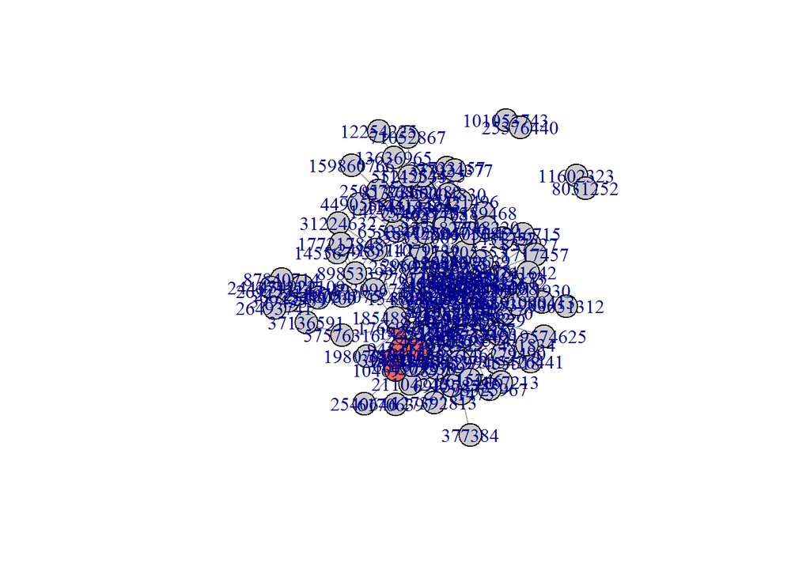

## 10. Кластеры (подгруппы, сообщества)

10а. Оптимальная кластеризация. Максимизируется “модулярность”. Это разность между долей ребер внутри сообщества и ожидаемой долей, если бы ребра были размещены случайно.
$$Q=1/2m \sum_{i,j} (A_{i,j} - \frac{d_i d_j}{2m} ) \delta(C_i C_j)$$

Перебираются все варианты. A - матрица смежности. d - степень вершины, С - метка = номер сообщества к которому относится вершина, $\delta$ - символ Кронекера.

```r
co=cluster_optimal(g, weights = NULL)
```

У меня процесс шел 12 часов, так что повторять это я не буду. Результат:

43030.92/60/60 = 12 часов

Это число 0.4532178 - точка отсчета для хорошей кластеризации. Хорошие алгоритмы дадут близкий результат. Сейчас состав группы изменился, так что получится нечто другое.

10б. Подгруппы на основе промежуточности ребер (алгоритм Ньюмана - Гирвана).

1. Подсчет центральности по промежуточности на всех ребрах графа.
2. Поочередное удаление ребер с самым большим коэффициентом.
3. Сообществами считаются оставшиеся связанные компоненты.
4. Процедура удаления завершается, когда модулярность достигает максимума .

```r
system.time({ceb <- cluster_edge_betweenness(g)})
```

```
##    user  system elapsed
##    0.36    0.00    0.39
```

Дендрограмма:

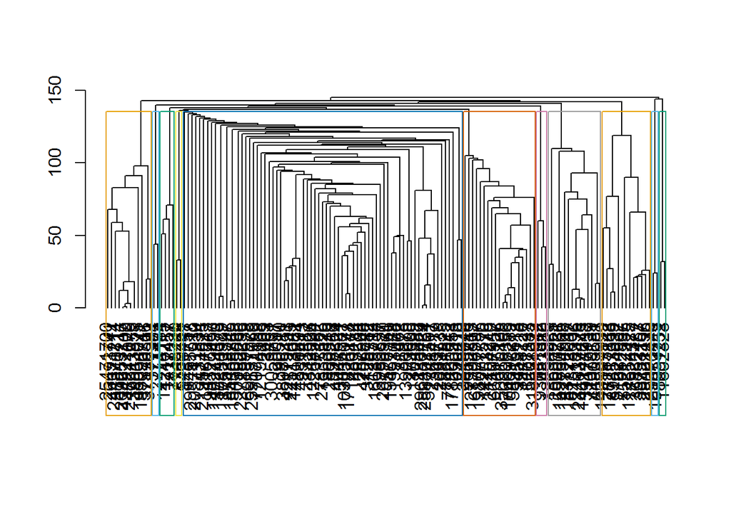

```r
dendPlot(ceb, mode="hclust")
```

Так себе, больше рисовать такое не буду.

Картинка с подкрашенными областями:

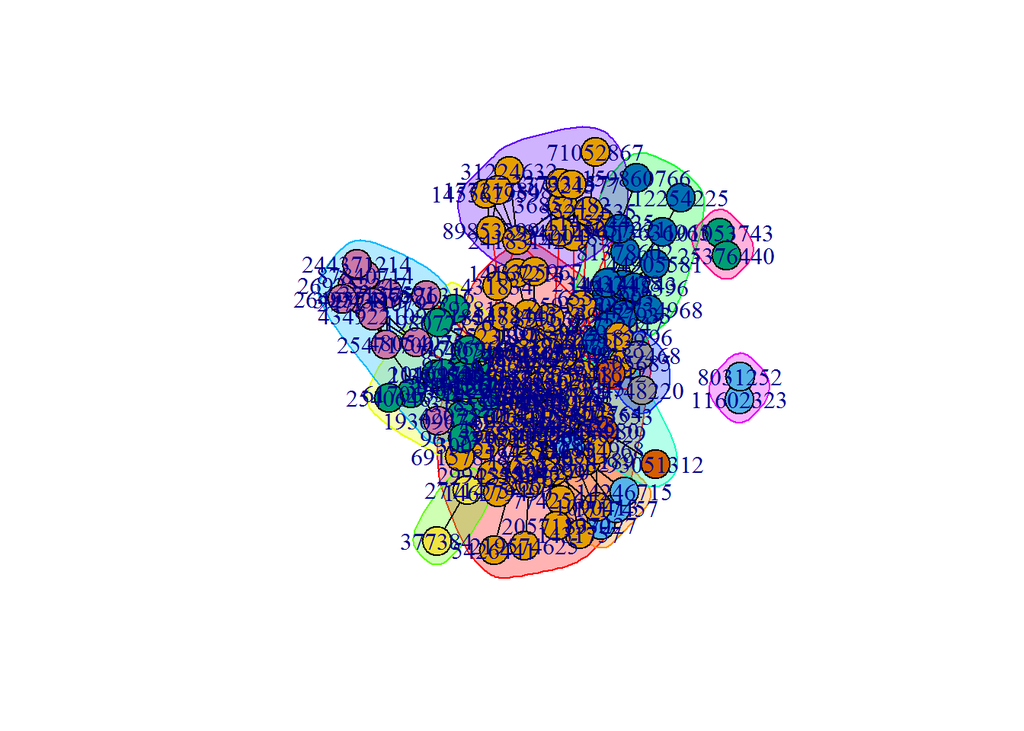

```r
plot(ceb, g)
```

Кто к какой подгруппе относится и численность подгрупп:

```r
membership(ceb)
```

```
##    403284   1343779   1353829   4206848      7462    126312    233887
##         1         1         1         1         1         1         1
##    246270    576361    837227   1717457   1993078   2693535  14246715
##         1         1         2         2         1         1         2
## 178205553     35978     71462   3128782   4896894  16638738  27835525
##         1         1         1         1         1         1         1
##  77425612    398266   1480474   2860319    287568  19457749  50505685
##         1         1         1         1         1         1         1
##   3985857  12268594 171826148    390510   4047624   5207333 318558672
##         1         1         1         1         1         3         3
##    273695   1304399   2368417  51741501 258802764 296486429   5426441
##         1         1         1         1         1         1         1
##   1090413   1431757  13906675  14113081  22512645  77074189   1881825
##         1         1         1         1         1         1         1
##   3446351   4342526 103034077 299455518   2771475  65533903  71079139
```

[output cut: 27 more lines]

```r
table(membership(ceb))
```

```
##
##  1  2  3  4  5  6  7  8  9 10 11
## 73  4 19  2 14  3 12  2 13  2  2
```

Качество разбиения оценим по модулярности:

```r
modularity(ceb)
```

```
## [1] 0.3893435
```

Заметно и прогнозируемо хуже, чем оптимальная модулярность.

10в. Разбиение распространением меток. Сначала узлы получают случайные номера. Затем, для каждого узла выбираем номер, той группы в которое входит большинство соседей. До тех пор, пока происходят изменения.Тут важен порядок перебора вершин. Алгоритм при разных запусках может выдать разные результаты.

Все основные функции сразу:

```r
system.time({clp <- cluster_label_prop(g)})
```

```
##    user  system elapsed
##       0       0       0
```

```r
table(membership(clp))
```

```
##
##   1   2   3   4   5   6   7   8
## 103  14  10   8   2   2   5   2
```

```r
modularity(clp)
```

```
## [1] 0.2864275
```

Картинка:

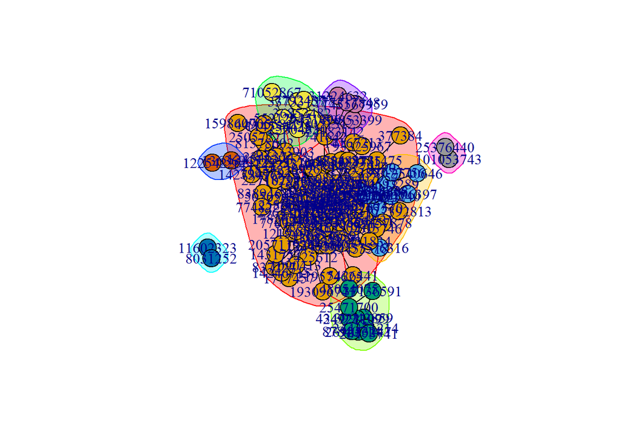

```r
plot(clp, g)
```

Подгрупп поменьше и модулярность не фонтан.

10г Жадная оптимизация (быстрый и жадный). 1. Инициализация сообществ в каждой вершине. 2. Объединение сообществ, в результате которого максимальным образом увеличивается модулярность. 3. Выход, если дальнейшее увеличение значения невозможно. Часто создает одну большую подгруппу и много мелких

```r
system.time({cfg <- cluster_fast_greedy(g)})
```

```
##    user  system elapsed
##       0       0       0
```

```r
table(membership(cfg))
```

```
##
##  1  2  3  4  5  6  7  8  9
## 30 27 13 38  6 16 12  2  2
```

```r
modularity(cfg)
```

```
## [1] 0.4711748
```

Модулярность достойная.

Картинка:

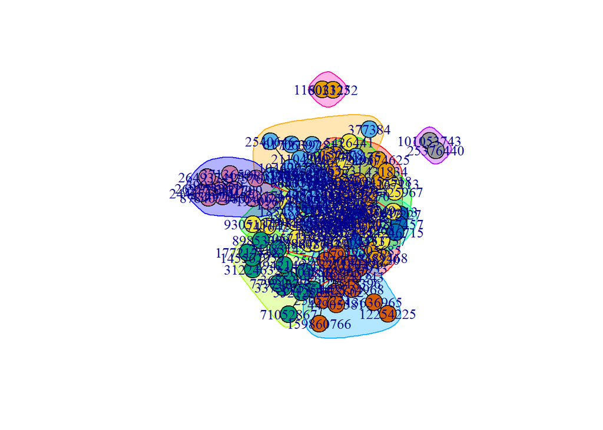

```r
plot(cfg, g)
```

10д Случайные блуждания. Если случайно переходить от узла к узлу, то большую часть времени проведешь внутри подгруппы. Так оно и работает.

```r
system.time({cwt <- cluster_walktrap(g)})
```

```
##    user  system elapsed
##       0       0       0
```

```r
table(membership(cwt))
```

```
##
##  1  2  3  4  5  6  7  8  9 10 11 12 13 14 15 16 17 18
## 57  7 13  3 22  2  2  5  2 12  4  8  2  2  2  1  1  1
```

```r
modularity(cwt)
```

```
## [1] 0.4394786
```

И

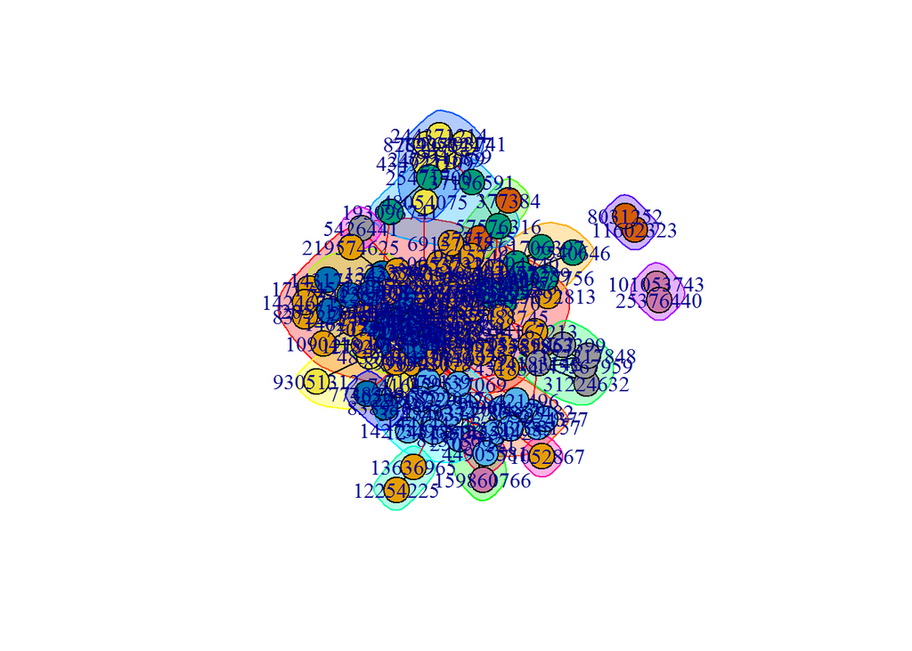

```r
plot(cwt, g)
```

## 11 K-ядерная декомпозиция

k-ядро это максимальная подгруппа, в которой каждый узел имеет степень k или больше.

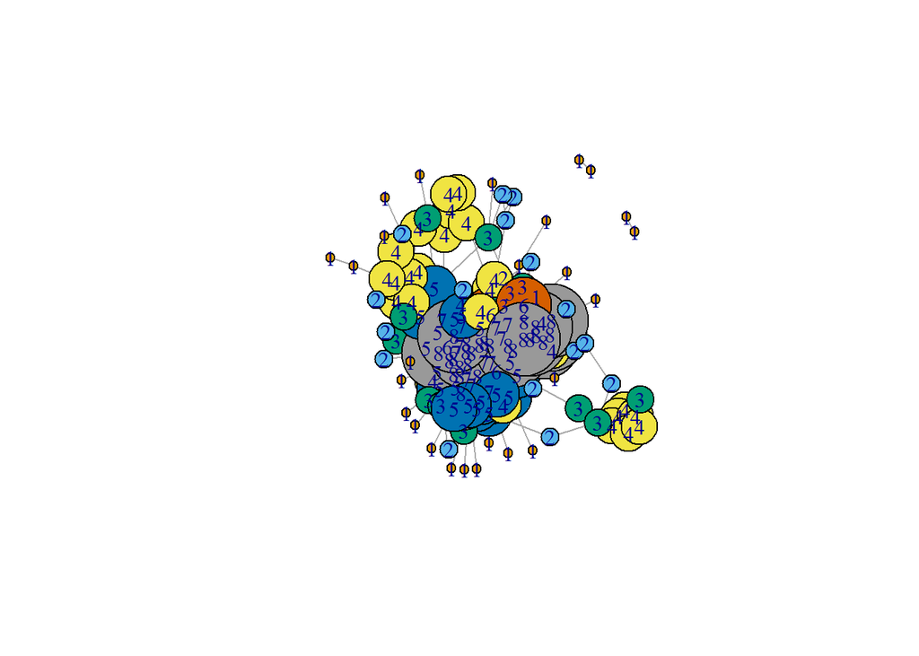

```r
kc <- coreness(g, mode="all")
plot(g, vertex.size=kc*6, vertex.label=kc, vertex.color=kc)
```

Эта операция делит всех на ядро и периферию нескольких уровней. Закончилась психология, началась социология. И на этой строке я решил остановится.